# Honors Project

### Question of interest

Which advertising medium (TV, radio, newspaper) has the strongest correlation with sales?

Independent Variables:  
TV, Radio, Newspaper

Dependent Variables:

Sales

```r
#Uploading and viewing data from data sets
ads_data <- read.csv("Advertising.csv")
head(ads_data)
```

|  | X | TV | radio | newspaper | sales |
| --- | --- | --- | --- | --- | --- |
| 1 | 1 | 230.1 | 37.8 | 69.2 | 22.1 |
| 2 | 2 | 44.5 | 39.3 | 45.1 | 10.4 |
| 3 | 3 | 17.2 | 45.9 | 69.3 | 9.3 |
| 4 | 4 | 151.5 | 41.3 | 58.5 | 18.5 |
| 5 | 5 | 180.8 | 10.8 | 58.4 | 12.9 |
| 6 | 6 | 8.7 | 48.9 | 75.0 | 7.2 |

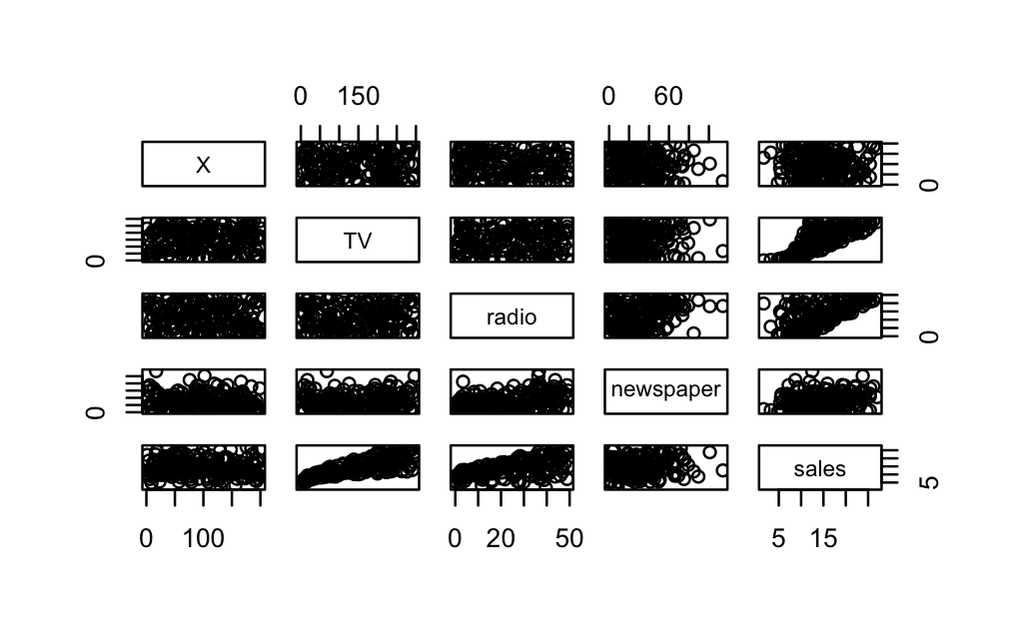

```r
plot(ads_data)
```

### Correlation Test

Below, we are calculating Pearson correlation coefficient between each predictor and the sales variable

The cor.test() function gives us t, df, andnp-value

Our Null hypothesis is that there is no correlation between advertising spending and sales

Alt Hypothesis: There is a significant correlation between advertising spending and sales

```r
# Correlation between TV budget and sales
tv_cor <- cor.test(ads_data$TV, ads_data$sales)
tv_cor
```

```
    Pearson's product-moment correlation

data:  ads_data$TV and ads_data$sales
t = 17.668, df = 198, p-value < 2.2e-16
alternative hypothesis: true correlation is not equal to 0
95 percent confidence interval:
 0.7218201 0.8308014
sample estimates:
      cor
0.7822244
```

```r
# Correlation between radio budget and sales
radio_cor <- cor.test(ads_data$radio, ads_data$sales)
radio_cor
```

```
    Pearson's product-moment correlation

data:  ads_data$radio and ads_data$sales
t = 9.9208, df = 198, p-value < 2.2e-16
alternative hypothesis: true correlation is not equal to 0
95 percent confidence interval:
 0.4754954 0.6620366
sample estimates:
      cor
0.5762226
```

```r
# Correlation between newspaper budget and sales
newspaper_cor <- cor.test(ads_data$newspaper, ads_data$sales)
newspaper_cor
```

```
    Pearson's product-moment correlation

data:  ads_data$newspaper and ads_data$sales
t = 3.2996, df = 198, p-value = 0.001148
alternative hypothesis: true correlation is not equal to 0
95 percent confidence interval:
 0.0924875 0.3557712
sample estimates:
     cor
0.228299
```

## Effect Size:

**Effect Size**:

The correlation coefficient itself can be interpreted as an effect size, where:

```
•   0.1 to 0.3 indicates a small effect,

•   0.3 to 0.5 indicates a medium effect,

•   0.5 or greater indicates a large effect.
```

Trends

1. **TV vs Sales**: This plot shows a strong positive relationship between TV advertising and sales, as indicated by the upward trend.
   2. **Radio vs Sales**: This plot shows a moderate positive relationship between radio advertising and sales, with a bit more scatter than TV.
   3. **Newspaper vs Sales**: This plot indicates a weaker relationship between newspaper advertising and sales, with the points more spread out and less of a clear trend.

```r
# Load the dataset
ads_data <- read.csv("Advertising.csv")

# Set up the plotting area with 3 plots side by side
par(mfrow = c(1, 3)) # Creates a 1x3 grid for the plots

# TV vs Sales
plot(ads_data$TV, ads_data$sales,
     main = "TV vs Sales",
     xlab = "TV Budget (Thousands)",
     ylab = "Sales (Thousands)",
     pch = 19, col = "blue")

# Radio vs Sales
plot(ads_data$radio, ads_data$sales,
     main = "Radio vs Sales",
     xlab = "Radio Budget (Thousands)",
     ylab = "Sales (Thousands)",
     pch = 19, col = "red")
```

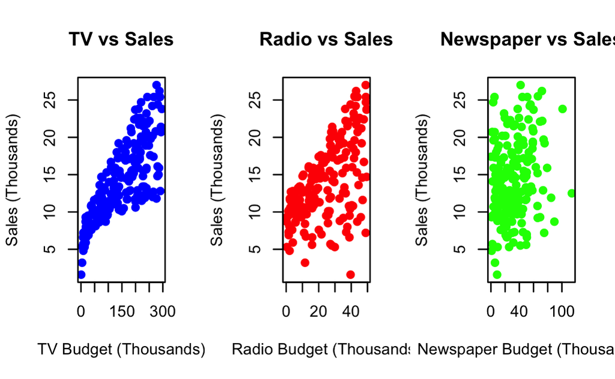

```r
# Newspaper vs Sales
plot(ads_data$newspaper, ads_data$sales,
     main = "Newspaper vs Sales",
     xlab = "Newspaper Budget (Thousands)",
     ylab = "Sales (Thousands)",
     pch = 19, col = "green")

# Reset the plotting area to default
par(mfrow = c(1, 1))
```

```
1.  TV Advertising and Sales:
```

The correlation coefficient is 0.782 with a 95% confidence interval of (0.722, 0.831). The p-value is extremely small (less than 2.2e-16), indicating that the correlation is highly statistically significant.

```
•   Interpretation: This shows a strong positive correlation between TV advertising budget and sales, meaning that as the TV advertising budget increases, sales are likely to increase significantly.

2.  Radio Advertising and Sales:
```

The correlation coefficient is 0.576 with a 95% confidence interval of (0.475, 0.662). The p-value is also less than 2.2e-16, indicating a statistically significant correlation.

```
•   Interpretation: This indicates a moderate positive correlation between radio advertising and sales. Radio advertising has a positive effect on sales, though it is not as strong as TV advertising.

3.  Newspaper Advertising and Sales:
```

The correlation coefficient is 0.228 with a 95% confidence interval of (0.092, 0.356). The p-value is 0.0011, which suggests that the correlation is statistically significant, but weaker than TV and radio.

```
•   Interpretation: This shows a weak positive correlation between newspaper advertising and sales, meaning that newspaper advertising has a minimal impact on sales compared to TV and radio.
```

## Overall:

The analysis shows that TV advertising has the most substantial impact on sales, followed by radio advertising with a moderate impact, and newspaper advertising with a relatively weak influence.